# individual1.Rmd

Jacob Shoemaker; jshoemaker2249

3/14/2019

Loading Data

```r
library(readxl)
defense <- read_excel("cyclonesFootball2018.xlsx", sheet = 'Defensive')
offense <- read_excel("cyclonesFootball2018.xlsx", sheet = 'Offensive')
biography <- read_excel("cyclonesFootball2018.xlsx", sheet = 'Biography')
```

Part one: Cleaning Data 1. Player and opponent names as factors

```r
library(dplyr)
```

```r
library(tidyr)
offense <- offense %>%
  rename(Opponent = Opponent_Opponent) %>%
  mutate(Opponent = factor(Opponent),
         Name = factor(Name))

defense <- defense %>%
  rename(Opponent = Opponent_Opponent) %>%
  mutate(Opponent = factor(Opponent),
         Name = factor(Name))

biography <- biography %>%
  mutate(Name = factor(Name))
```

2. Stats are numerical

```r
library(dplyr)
library(tidyr)
defense <- defense %>%
  mutate(Tackles_Solo = as.numeric(Tackles_Solo),
         Tackles_ASST = as.numeric(Tackles_ASST),
         Tackles_TFL = as.numeric(Tackles_TFL),
         Tackles_Sack = as.numeric(Tackles_Sack),
         Turnover_FF = as.numeric(Turnover_FF),
         Turnover_FR = as.numeric(Turnover_FR),
         Turnover_INT = as.numeric(Turnover_INT),
         Pass_QBH = as.numeric(Pass_QBH),
         Pass_PB = as.numeric(Pass_PB))

offense <- offense %>%
  rename(Passing_CMP_ATT = "Passing_CMP-ATT")

offense <- offense %>%
  mutate(Receiving_REC = as.numeric(Receiving_REC),
         Receiving_YDS = as.numeric(Receiving_YDS),
         Receiving_TD = as.numeric(Receiving_TD),
         Rushing_ATT = as.numeric(Rushing_ATT),
         Rushing_YDS = as.numeric(Rushing_YDS),
         Rushing_TD = as.numeric(Rushing_TD),
         Passing_YDS = as.numeric(Passing_YDS),
         Passing_TD = as.numeric(Passing_TD),
         Passing_INT = as.numeric(Passing_INT))

offense <- separate(offense, "Passing_CMP_ATT", c("Passing_CMP", "Passing_ATT"), sep= "-\r\n")

offense <- offense %>%
  mutate(Passing_CMP = as.numeric("Passing_CMP"),
         Passing_ATT = as.numeric("Passing_ATT"))
```

```r
biography <- biography %>% mutate(Weight = as.numeric(Weight))

offClean <- offense
defClean <- defense
bioClean <- biography

str(offClean)
```

```
## Classes 'tbl_df', 'tbl' and 'data.frame':    168 obs. of  13 variables:
##  $ Name         : Factor w/ 15 levels "Akers, Landen",..: 6 6 6 6 6 6 6 6 6 6 ...
##  $ Opponent     : Factor w/ 13 levels "Akron","Baylor",..: 4 7 1 9 8 13 11 5 2 10 ...
##  $ Receiving_REC: num  1 9 6 3 6 1 1 4 4 0 ...
##  $ Receiving_YDS: num  31 66 39 23 37 32 4 31 39 0 ...
##  $ Receiving_TD : num  0 0 0 0 1 1 0 0 1 0 ...
##  $ Rushing_ATT  : num  NA NA NA NA NA NA NA NA NA NA ...
##  $ Rushing_YDS  : num  NA NA NA NA NA NA NA NA NA NA ...
##  $ Rushing_TD   : num  NA NA NA NA NA NA NA NA NA NA ...
##  $ Passing_CMP  : num  NA NA NA NA NA NA NA NA NA NA ...
##  $ Passing_ATT  : num  NA NA NA NA NA NA NA NA NA NA ...
##  $ Passing_YDS  : num  NA NA NA NA NA NA NA NA NA NA ...
##  $ Passing_TD   : num  NA NA NA NA NA NA NA NA NA NA ...
##  $ Passing_INT  : num  NA NA NA NA NA NA NA NA NA NA ...
```

```r
str(defClean)
```

```
## Classes 'tbl_df', 'tbl' and 'data.frame':    446 obs. of  11 variables:
##  $ Name        : Factor w/ 42 levels "Akers, Landen",..: 7 7 7 7 7 7 7 7 7 7 ...
##  $ Opponent    : Factor w/ 13 levels "Akron","Baylor",..: 4 7 1 9 8 13 11 5 2 10 ...
##  $ Tackles_Solo: num  3 6 7 6 3 5 3 7 2 9 ...
##  $ Tackles_ASST: num  3 8 2 3 0 3 2 1 4 3 ...
##  $ Tackles_TFL : num  0 1 1 0 1 1 0 0 0 0 ...
##  $ Tackles_Sack: num  0 0 0 0 0 1 0 0 0 0 ...
##  $ Turnover_FF : num  0 1 0 0 0 0 0 0 0 1 ...
##  $ Turnover_FR : num  0 0 0 0 0 0 0 0 0 0 ...
##  $ Turnover_INT: num  0 0 0 0 0 0 1 0 0 0 ...
##  $ Pass_QBH    : num  0 0 0 0 0 0 0 0 0 0 ...
##  $ Pass_PB     : num  0 0 3 0 0 0 0 0 0 0 ...
```

```r
str(bioClean)
```

```
## Classes 'tbl_df', 'tbl' and 'data.frame':    123 obs. of  7 variables:
##  $ Name      : Factor w/ 123 levels "Akers, Landen",..: 1 2 3 4 5 6 7 8 9 10 ...
##  $ Position  : chr  "Wide Receiver" "Tight End" "Offensive Line" "Tight End" ...
##  $ Height    : chr  "6-0" "6-7" "6-2" "6-4" ...
##  $ Weight    : num  192 240 290 250 191 205 192 224 251 284 ...
##  $ Class     : chr  "Redshirt Sophomore" "Redshirt Sophomore" "Redshirt Freshman" "Redshirt Senior" ...
##  $ Hometown  : chr  "Cedar Rapids, Iowa" "Nixa, Mo." "Cedar Rapids, Iowa" "League City, Texas" ...
##  $ Highschool: chr  "Washington" "Nixa" "Washington" "Clear Falls" ...
```

Part two: Tidying (1)

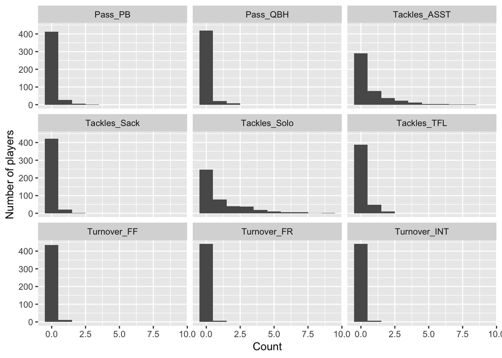

```r
defClean <- defClean %>% gather(key= Statistic, value = Count, 3:11)
library(ggplot2)
ggplot(defClean, aes(x=Count)) +geom_histogram(bins=10) + facet_wrap(~Statistic) + ylab("Number of players")
```

Kansas State vs. West Virginia

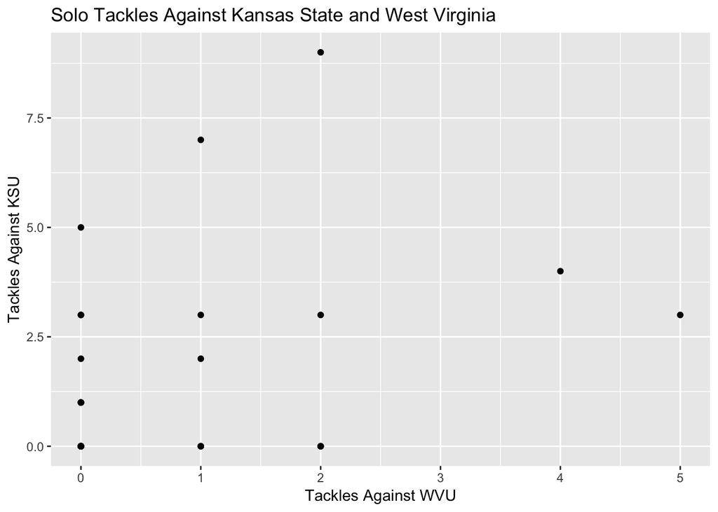

```r
defClean_Solo <- defClean[defClean$Statistic=='Tackles_Solo',] %>% group_by(Name)
complete <- filter(defClean_Solo, Opponent=='West Virginia' | Opponent=='Kansas State')%>% spread(key=Opponent, value=Count)
names(complete) <- c('Name', 'Statisitic', 'KSU','WVU')
complete[is.na(complete)] <- 0
ggplot(complete, aes(x=WVU, y=KSU), group_by(Name)) + geom_point()+xlab("Tackles Against WVU") + ylab("Tackles Against KSU") + ggtitle("Solo Tackles Against Kansas State and West Virginia")
```

From this, I would determine that better defense was played against Kansas State. While there are not many players that had a large number of solo tackles in both games, there was a larger clump of players that had between 1-4 solo tackles against KSU, that did not perform well against WVU. Therefore, those small increments of fewer tackles led to more overall solo tackles against Kansas State.

Part two: Tidying (2)

```r
bioClean <- separate(bioClean, "Hometown", c('City', 'State'), sep = ", ")
a <- bioClean %>% group_by(State) %>% summarise(Num_Players = n())
a
```

```
## # A tibble: 25 x 2
##    State     Num_Players
##    <chr>           <int>
##  1 Ariz.               3
##  2 Ark.                2
##  3 Australia           2
##  4 Calif.              8
##  5 D.C.                1
##  6 Fla.                8
##  7 Ga.                 2
##  8 Ill.                5
##  9 Iowa               44
## 10 Kan.                3
## # … with 15 more rows
```

Part three: Joining data frames

```r
offJoin <- left_join(offClean, bioClean, by= 'Name')
```

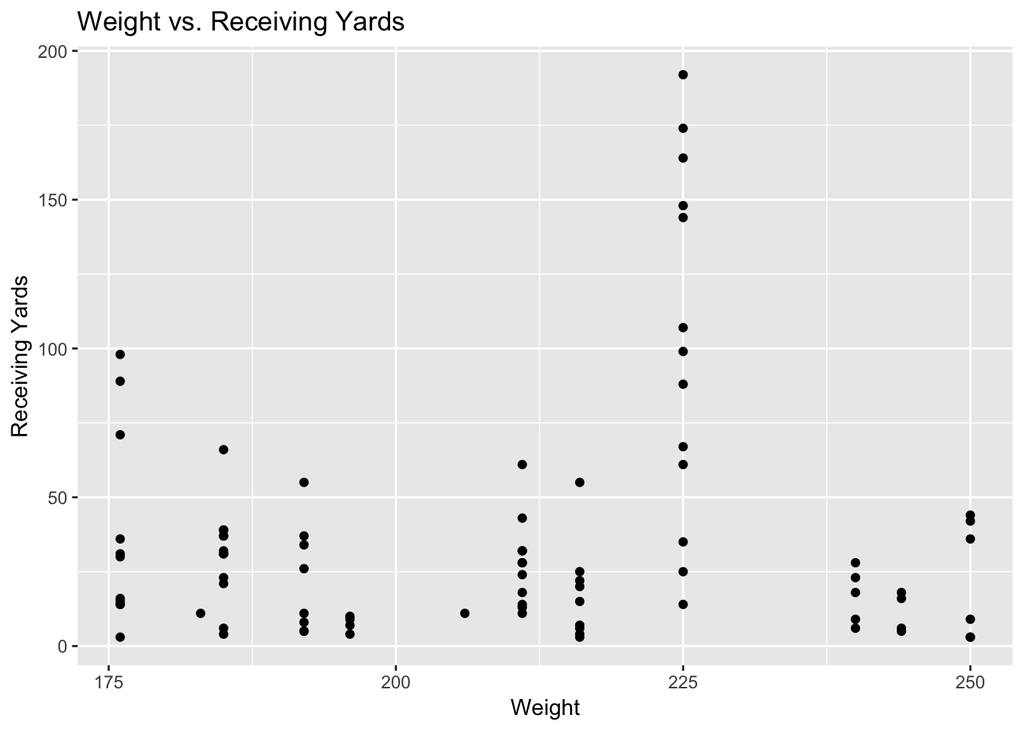

```r
yrds <- offJoin[offJoin$Receiving_YDS != 0,] %>% filter(!is.na(Name))
ggplot(yrds, aes(x= Weight, y = Receiving_YDS)) + geom_point() + ggtitle("Weight vs. Receiving Yards") + xlab("Weight") + ylab("Receiving Yards")
```

I would claim that there is not much of a trend between receiving yards and weight once a receiver weighs around 200lbs. The only receiver listed at 225 is Hakeem Butler, so it would make sense that there are outliers for his performance.

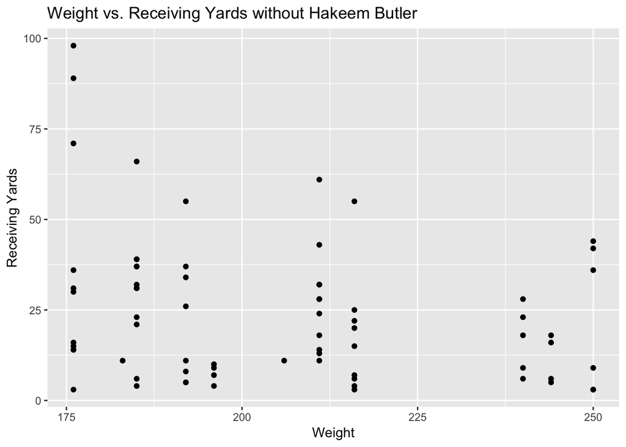

```r
noHakeem <- yrds[yrds$Name != "Butler, Hakeem", ]
ggplot(noHakeem, aes(x= Weight, y = Receiving_YDS)) + geom_point() + ggtitle("Weight vs. Receiving Yards without Hakeem Butler") + xlab("Weight") + ylab("Receiving Yards")
```

Examining the dataset without Hakeem Butler, it further shows that the distribution is fairly even. Therefore, I would claim that weight is not as important to receiving yards. However, it probably would have a stronger relationship with yards after catch (data not included in the offClean dataset).

For my own exploration, I wanted to look at height vs receiving yards, rather than weight. I would expect this to take a more positive linear relationship, as taller receivers tend to be more successful given equal levels of athleticism.

```r
bioClean <- separate(bioClean, "Height", c('Feet', 'Inches'), sep = "-")
bioClean <- bioClean %>% mutate(Feet = as.numeric(Feet), Inches = as.numeric(Inches))
bioClean <- bioClean %>% mutate(Height = (Feet*12) + Inches)

offJoinH <- left_join(offClean, bioClean, by= 'Name')
```

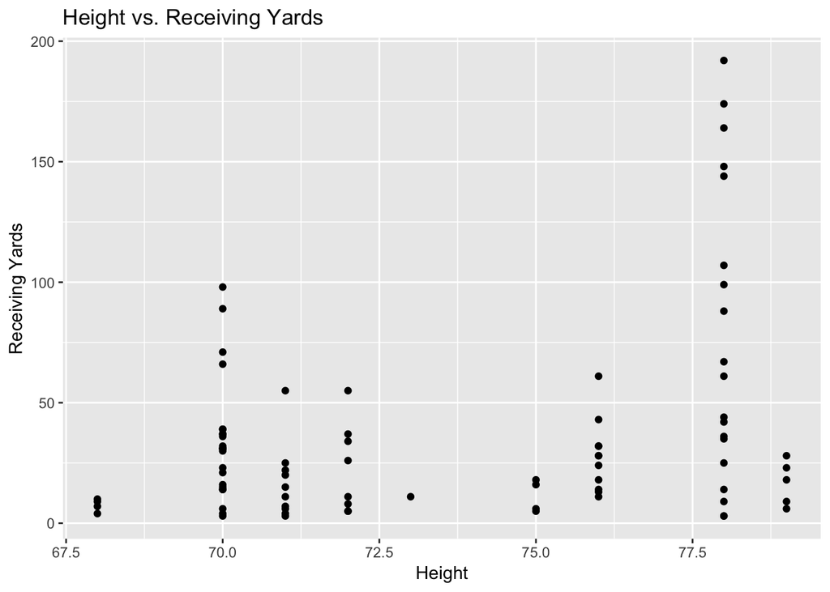

```r
yrdsH <- offJoinH[offJoinH$Receiving_YDS != 0,] %>% filter(!is.na(Name))
ggplot(yrdsH, aes(x= Height, y = Receiving_YDS)) + geom_point() + ggtitle("Height vs. Receiving Yards") + xlab("Height") + ylab("Receiving Yards")
```

This surprised me a little to see that the tallest receivers were not the most successful in terms of overall yards. However, it is important to note that taller receivers may have more trouble if they get pushed around, as well as the fact that the Iowa State receiving corps is not all that deep.